# Response variable - Q26 (Confidence Level)

5개 category 로 fitting 한 결과 accuracy = 0.3내외 --> 매우 낮음  
따라서 애매한 중간 카테고리를 Middle로 대체해 HIGH, MIDDLE, LOW 로 분류

- country : 대륙으로 그룹화
- 직무 : 4가지로 그룹화  
  각 role과 confidence cor 확인 결과 data scienties, software engineer, student 외로 별다른 특성이 없어 others로 대체
- 연봉 : I do not wish to ~~ / NA제외  
  국가와의 correlation이 높을 것으로 예상됨 - 다중공선성을 우려하여 나라별 평균 연봉 대비 비율로 계산  
  연봉의 하한선을 기준으로 계산
- 28, 29, 30 : Google, IBM, Azure 등 기업 기준으로 그룹화
- 34, 35 등 10단위로 나오는 변수들은 100으로 나눠 scale
- 37제외(NA값 너무많음)
- 다중공선성을 고려하여 correlation 0.5 이상인 변수들은 제거 :  
  ['1_Male', '4_Master’s degree', '6_0_Others', '7_I am a student', '14_None', '15_I have not used any cloud providers', '16_R', '16_MATLAB', '19_Keras', '19_None', '21_ggplot2', '21*Matplotlib', '25*< 1 year', '27_AWS Elastic Compute Cloud (EC2)', '27_Google Compute Engine', '27_Azure Virtual Machines', '36_Fast.AI', '42_Not applicable (I am not involved with an organization that builds ML models)', '44_I have never performed this task', '28_IBM', '29_SQL', '30_Google']
- Q17, 18, 20, 22, 33 은 전과 같은 이유로 제외
- 1의 비율이 5% 이하인 column 제외
- 총 234개 변수로 fitting
- metrics: accuracy
- RF, Linear SVM, MLP, LDA, LightGBM으로 accuracy 산정한 결과, RF와 LightGBM이 가장 높은 성능을 보여 둘을 채택.
- GridSearchCV를 사용해 hyperparameter tuning
- test 결과 오버피팅은 보이지 않았음.
- lightGBM과 RF의 feature importance를 참고하여 중요변수를 산정.

```python
import pandas as pd
import numpy as np
import matplotlib.pyplot as plt
import seaborn as sns
from sklearn import preprocessing
sns.set_style('dark')

%matplotlib inline
plt.style.use('fivethirtyeight')
```

```python
data=pd.read_csv('data/responses.csv')
```

```python
qs=pd.read_csv('data/SurveySchema.csv')
```

```python
data.head()
```

|  | Time from Start to Finish (seconds) | Q1 | Q1_OTHER_TEXT | Q2 | Q3 | Q4 | Q5 | Q6 | Q6_OTHER_TEXT | Q7 | ... | Q49_OTHER_TEXT | Q50_Part_1 | Q50_Part_2 | Q50_Part_3 | Q50_Part_4 | Q50_Part_5 | Q50_Part_6 | Q50_Part_7 | Q50_Part_8 | Q50_OTHER_TEXT |
| --- | --- | --- | --- | --- | --- | --- | --- | --- | --- | --- | --- | --- | --- | --- | --- | --- | --- | --- | --- | --- | --- |
| 0 | Duration (in seconds) | What is your gender? - Selected Choice | What is your gender? - Prefer to self-describe... | What is your age (# years)? | In which country do you currently reside? | What is the highest level of formal education ... | Which best describes your undergraduate major?... | Select the title most similar to your current ... | Select the title most similar to your current ... | In what industry is your current employer/cont... | ... | What tools and methods do you use to make your... | What barriers prevent you from making your wor... | What barriers prevent you from making your wor... | What barriers prevent you from making your wor... | What barriers prevent you from making your wor... | What barriers prevent you from making your wor... | What barriers prevent you from making your wor... | What barriers prevent you from making your wor... | What barriers prevent you from making your wor... | What barriers prevent you from making your wor... |
| 1 | 710 | Female | -1 | 45-49 | United States of America | Doctoral degree | Other | Consultant | -1 | Other | ... | -1 | NaN | NaN | NaN | NaN | NaN | NaN | NaN | NaN | -1 |
| 2 | 434 | Male | -1 | 30-34 | Indonesia | Bachelor’s degree | Engineering (non-computer focused) | Other | 0 | Manufacturing/Fabrication | ... | -1 | NaN | NaN | NaN | NaN | NaN | NaN | NaN | NaN | -1 |
| 3 | 718 | Female | -1 | 30-34 | United States of America | Master’s degree | Computer science (software engineering, etc.) | Data Scientist | -1 | I am a student | ... | -1 | NaN | Too time-consuming | NaN | NaN | NaN | NaN | NaN | NaN | -1 |
| 4 | 621 | Male | -1 | 35-39 | United States of America | Master’s degree | Social sciences (anthropology, psychology, soc... | Not employed | -1 | NaN | ... | -1 | NaN | NaN | Requires too much technical knowledge | NaN | Not enough incentives to share my work | NaN | NaN | NaN | -1 |

5 rows × 395 columns

```python
data=data.iloc[1:,:]
data = data.reset_index()
data=data.iloc[:,1:]
```

```python
indexna = data.Q26[data.Q26.isna()].index
indexnona = data.Q26[~data.Q26.isna()].index
```

```python
na = data.iloc[indexna,0]
nona = data.iloc[indexnona,0]
```

```python
na = na.reset_index().drop(['index'],axis=1)
nona = nona.reset_index().drop(['index'],axis=1)
```

```python
na.columns = ['time']
nona.columns = ['time']
```

```
{'whiskers': [<matplotlib.lines.Line2D at 0x17eade00248>,
 'caps': [<matplotlib.lines.Line2D at 0x17eadcff208>,
 'boxes': [<matplotlib.lines.Line2D at 0x17eadd8c1c8>],
 'medians': [<matplotlib.lines.Line2D at 0x17eadd224c8>],
 'fliers': [<matplotlib.lines.Line2D at 0x17eadd223c8>],
 'means': []}
```

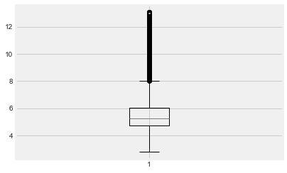

```python
plt.boxplot(np.log(list(na.iloc[:,0])))
```

```
{'whiskers': [<matplotlib.lines.Line2D at 0x17eadcf99c8>,
 'caps': [<matplotlib.lines.Line2D at 0x17eadea5608>,
 'boxes': [<matplotlib.lines.Line2D at 0x17eadd3e7c8>],
 'medians': [<matplotlib.lines.Line2D at 0x17eade3dac8>],
 'fliers': [<matplotlib.lines.Line2D at 0x17eadda7088>],
 'means': []}
```

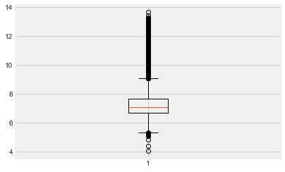

```python
plt.boxplot(np.log(list(pd.to_numeric(nona.iloc[:,0]))))
```

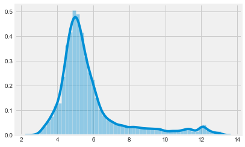

```python
sns.distplot(np.log(list(na.iloc[:,0])))
```

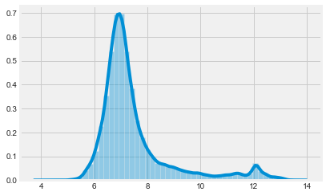

```python
sns.distplot(np.log(list(pd.to_numeric(nona.iloc[:,0]))))
```

NA 데이터 : e^5(=148)초에서 중단되는 경우가 다수.  
그에 반해 NA가 아닌 데이터는 응답 중단 시간이 대부분 148초를 넘어감 => NA = 테스트 도중 나가버렸을 가능성 ↑  
따라서 제외해도 무방

## Response variable - Q26 (Confidence Level)

- 5개 category 로 fitting 한 결과 accuracy = 0.3내외 --> 매우 낮음
- 따라서 애매한 중간 카테고리를 Middle로 대체해 HIGH, MIDDLE, LOW 로 분류

```python
len(data.Q26[data.Q26.isna()])
```

```
5379
```

```python
##NA값 제거
data=data.drop(data.Q26[data.Q26.isna()].index, axis=0)
```

```python
data=data.reset_index()
data=data.iloc[:,1:]
```

```python
data.shape
```

```
(18480, 395)
```

```python
conf = data.Q26
conf.unique()
```

```
array(['Maybe', 'Definitely not', 'Definitely yes', 'Probably yes',
       'Probably not'], dtype=object)
```

```python
encode = {'Definitely not':'LOW','Probably not':'MIDDLE','Maybe':'MIDDLE','Probably yes':'MIDDLE','Definitely yes':'HIGH'}
data.Q26.replace(encode,inplace = True)
```

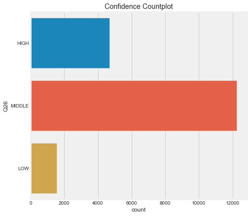

```python
plt.figure(figsize=(7,7))
sns.countplot(y=data.Q26, order = ['HIGH','MIDDLE','LOW'])
plt.title('Confidence Countplot')
plt.show()
```

```python
confdummy = pd.get_dummies(conf)
```

```python
#numeric encoding
encode = {'LOW':0,'MIDDLE':1,'HIGH':2}
conf = conf.replace(encode)
```

```python
new_index = ['LOW','MIDDLE','HIGH']
confdummy=confdummy.reindex(new_index, axis="columns")
```

```python
ndata = pd.DataFrame()
```

## Duration(제외), Q1-Q10

```python
data.Q1.unique()
```

```
array(['Female', 'Male', 'Prefer not to say', 'Prefer to self-describe'],
      dtype=object)
```

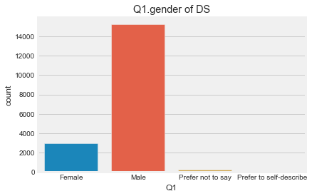

```python
sns.countplot(data.Q1)
plt.title('Q1.gender of DS')
plt.show()
```

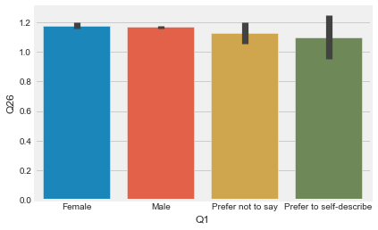

```python
sns.barplot(x=data.Q1,y=conf)
```

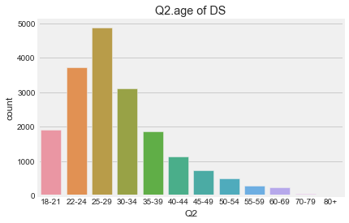

```python
sns.countplot(data.Q2,order=sorted(data.Q2.unique()))
plt.title('Q2.age of DS')
plt.show()
```

```python
# one hot encoding 후 prefer not to say, prefer to self-describe 제외
sex = pd.get_dummies(data.Q1).iloc[:,:2]
sex.columns=list(map(lambda x:'1_'+x,sex.columns))
ndata = pd.concat([ndata,sex],axis=1)
ndata.head()
```

|  | 1_Female | 1_Male |
| --- | --- | --- |
| 0 | 1 | 0 |
| 1 | 0 | 1 |
| 2 | 1 | 0 |
| 3 | 0 | 1 |
| 4 | 0 | 1 |

```python
ndata.shape
```

```
(18480, 2)
```

**나이 - numeric encoding**

```python
le = preprocessing.LabelEncoder()
```

```python
le.fit(data.Q2)
le.classes_
```

```
array(['18-21', '22-24', '25-29', '30-34', '35-39', '40-44', '45-49',
       '50-54', '55-59', '60-69', '70-79', '80+'], dtype=object)
```

```python
age = le.transform(data.Q2)
age = pd.Series(age)
age=age.rename('age')
ndata=pd.concat([ndata,age],axis=1)
```

```python
ndata.info()
```

```
<class 'pandas.core.frame.DataFrame'>
RangeIndex: 18480 entries, 0 to 18479
Data columns (total 3 columns):
1_Female    18480 non-null uint8
1_Male      18480 non-null uint8
age         18480 non-null int32
dtypes: int32(1), uint8(2)
memory usage: 108.4 KB
```

**country - onehot encoding**

```python
data.Q3.replace({'Republic of Korea':'South Korea'},inplace=True)
```

```python
asia=["Bangladesh","China","Hong Kong (S.A.R.)","India","Indonesia","Iran, Islamic Republic of...","Israel",
          "Japan","Malaysia","Pakistan","Philippines","Singapore","South Korea","Thailand",
          "Turkey","Viet Nam"]
europe =["Austria","Belarus","Belgium","Czech Republic","Denmark","Finland","France","Germany","Greece",
            "Hungary","Ireland","Italy","Netherlands","Norway","Poland","Portugal","Romania","Russia","Spain",
            "Sweden","Switzerland","Ukraine","United Kingdom of Great Britain and Northern Ireland"]
southamerica =["Argentina","Brazil","Chile","Colombia","Peru"]
northamerica =["Canada","Mexico","United States of America"]
oceania =["Australia","New Zealand"]
africa =["Egypt","Kenya","Morocco","Nigeria","South Africa","Tunisia"]
```

```python
def groupregion(x):
    if x in asia:
        x = 'Asia'
    elif x in europe:
        x = 'Europe'
    elif x in southamerica:
        x = 'SouthAmerica'
    elif x in northamerica:
        x = 'NorthAmerica'
    elif x in oceania:
        x='Oceania'
    else:
        x='Africa'
    return x

q3_grouped = [groupregion(x) for x in data.Q3]
```

```python
q3_grouped = pd.Series(q3_grouped)
```

```python
q3_grouped.unique()
```

```
array(['NorthAmerica', 'Asia', 'SouthAmerica', 'Europe', 'Africa',
       'Oceania'], dtype=object)
```

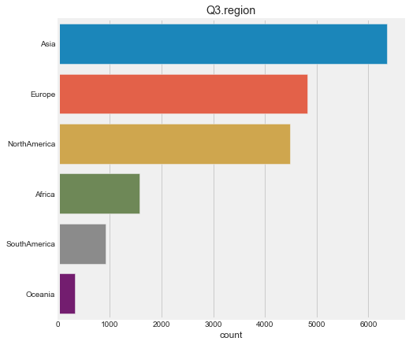

```python
plt.figure(figsize=(7,7))
sns.countplot(y=q3_grouped, order =q3_grouped.value_counts().index)
plt.title('Q3.region')
plt.show()
```

```python
q3=pd.get_dummies(q3_grouped)
cor_mat=pd.concat([confdummy,q3], axis=1, keys=['roledummy','q4']).corr().loc['roledummy','q4']
```

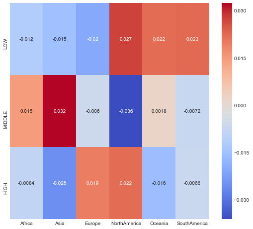

```python
plt.figure(figsize=(8,8))
sns.heatmap(cor_mat,cmap='coolwarm',annot=True)
plt.show()
```

Africa, Asia => MIDDLE  
Europe => HIGH  
NorthAmerica => HIGH or LOW --> 자기 확신이 강함  
Oceania, SouthAmerica => LOW

```python
q3.columns=list(map(lambda x: '3_'+x,q3.columns))
ndata = pd.concat([ndata,q3],axis=1)
```

**education degree** - onehot

```python
data.Q4.unique()
```

```
array(['Doctoral degree', 'Bachelor’s degree', 'Master’s degree',
       'Professional degree',
       'Some college/university study without earning a bachelor’s degree',
       'I prefer not to answer', 'No formal education past high school'],
      dtype=object)
```

```python
q4 = pd.get_dummies(data.Q4)
cor_mat=pd.concat([confdummy,q4], axis=1, keys=['roledummy','q4']).corr().loc['roledummy','q4']
```

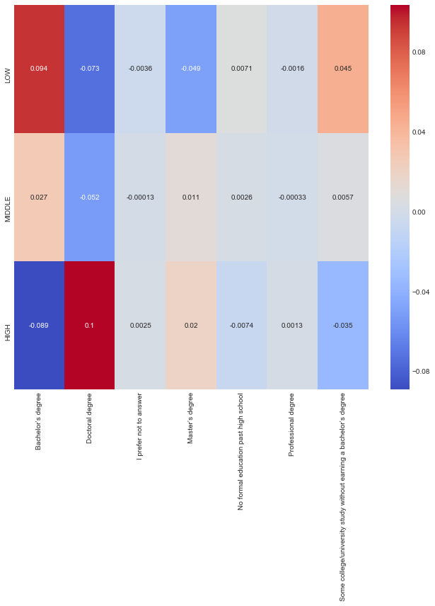

```python
plt.figure(figsize=(10,10))
sns.heatmap(cor_mat,cmap='coolwarm',annot=True)
plt.show()
```

```python
q4.columns=list(map(lambda x: '4_'+x,q4.columns))
ndata = pd.concat([ndata,q4],axis=1)
```

**전공**

```python
data.Q5.unique()
```

```
array(['Other', 'Engineering (non-computer focused)',
       'Computer science (software engineering, etc.)',
       'Social sciences (anthropology, psychology, sociology, etc.)',
       'Mathematics or statistics', 'Physics or astronomy',
       'Information technology, networking, or system administration',
       'A business discipline (accounting, economics, finance, etc.)',
       'Environmental science or geology',
       'Medical or life sciences (biology, chemistry, medicine, etc.)',
       'I never declared a major',
       'Humanities (history, literature, philosophy, etc.)', nan,
       'Fine arts or performing arts'], dtype=object)
```

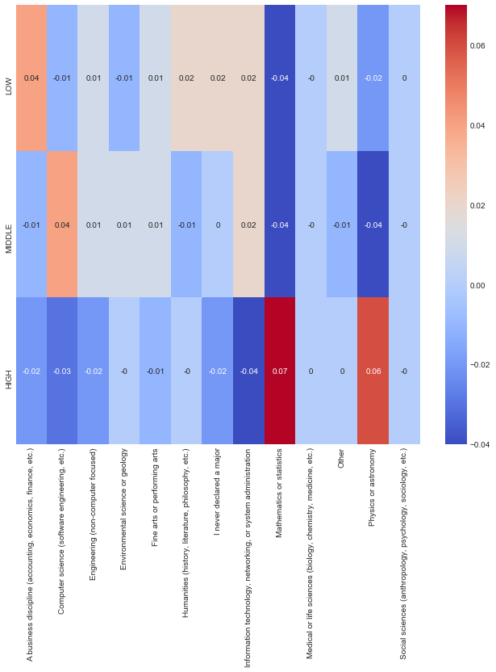

```python
q5 = pd.get_dummies(data.Q5)
cor_mat=round(pd.concat([confdummy,q5],axis=1,keys=['role','q5']).corr().loc['role','q5'],2)
plt.figure(figsize=(10,10))
sns.heatmap(cor_mat, cmap='coolwarm',annot=True)
```

# Q6. 직무 - 4가지로 그룹화

```python
def grouprole(x):
    if x not in ['Data Scientist','Software Engineer','Student']:
        return 'Others'
    else:
        return x

q6_grouped = [grouprole(x) for x in data.Q6]
```

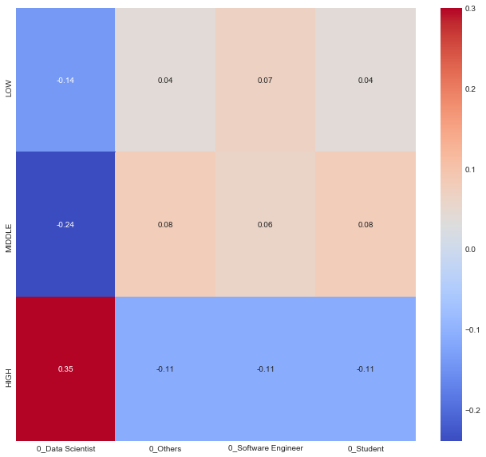

```python
q6 = pd.get_dummies(pd.DataFrame(q6_grouped))
cor_mat=round(pd.concat([confdummy,q6],axis=1,keys=['role','q7']).corr().loc['role','q7'],2)
plt.figure(figsize=(10,10))
sns.heatmap(cor_mat, cmap='coolwarm',vmax=0.3,annot=True)
```

```python
q6.columns=list(map(lambda x: '6_'+x,q6.columns))
ndata = pd.concat([ndata,q6],axis=1)
```

**산업군**

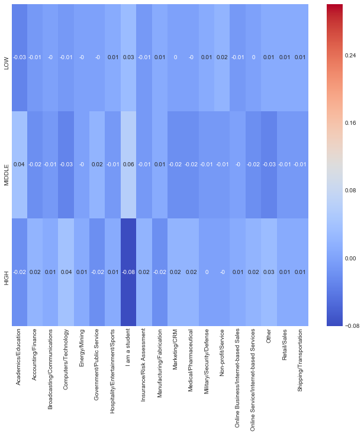

```python
q7 = pd.get_dummies(data.Q7)
cor_mat=round(pd.concat([confdummy,q7],axis=1,keys=['role','q7']).corr().loc['role','q7'],2)
plt.figure(figsize=(10,10))
sns.heatmap(cor_mat, cmap='coolwarm',vmax=0.3,annot=True)
```

```python
q7.columns=list(map(lambda x: '7_'+x,q7.columns))
ndata = pd.concat([ndata,q7],axis=1)
```

**경력**

```python
data.Q8.unique() #range가 고르지 않아서 onehot encoding으로.
```

```
array([nan, '5-10', '0-1', '10-15', '3-4', '1-2', '2-3', '15-20', '4-5',
       '20-25', '25-30', '30 +'], dtype=object)
```

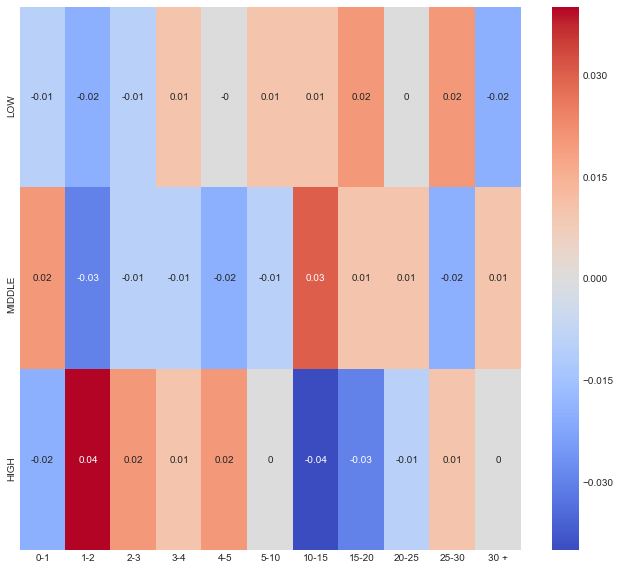

```python
q8 = pd.get_dummies(data.Q8)
q8=q8.reindex(columns=['0-1','1-2','2-3','3-4','4-5','5-10','10-15','15-20', '20-25', '25-30', '30 +' ])
cor_mat=round(pd.concat([confdummy,q8],axis=1,keys=['role','q']).corr().loc['role','q'],2)
plt.figure(figsize=(10,10))
sns.heatmap(cor_mat, cmap='coolwarm',annot=True)
```

```python
q8.columns=list(map(lambda x: '8_'+x,q8.columns))
ndata = pd.concat([ndata,q8],axis=1)
```

**연봉**

- I do not wish to ~~ / NA제외
- 국가와의 correlation이 높을 것으로 예상됨 - 다중공선성을 우려하여 나라별 평균 연봉 대비 비율로 계산
- 연봉의 하한선을 기준으로 계산

```python
gni = pd.read_csv('gni.csv')
```

```python
data.Q9.unique()
```

```
array([nan, '10-20,000', '0-10,000',
       'I do not wish to disclose my approximate yearly compensation',
       '20-30,000', '125-150,000', '30-40,000', '50-60,000',
       '100-125,000', '90-100,000', '70-80,000', '80-90,000', '60-70,000',
       '400-500,000', '40-50,000', '150-200,000', '500,000+',
       '300-400,000', '200-250,000', '250-300,000'], dtype=object)
```

```python
ndata = ndata[~data.Q9.isna()]
ndata = ndata[data.Q9!='I do not wish to disclose my approximate yearly compensation']
data = data[~data.Q9.isna()]
data = data[data.Q9!='I do not wish to disclose my approximate yearly compensation']
```

```python
data.shape
```

```
(13406, 395)
```

```python
ndata.shape
```

```
(13406, 50)
```

```python
data.Q9.unique()
```

```
array(['10-20,000', '0-10,000', '20-30,000', '125-150,000', '30-40,000',
       '50-60,000', '100-125,000', '90-100,000', '70-80,000', '80-90,000',
       '60-70,000', '400-500,000', '40-50,000', '150-200,000', '500,000+',
       '300-400,000', '200-250,000', '250-300,000'], dtype=object)
```

```python
encode = {'10-20,000':10000, '0-10,000':0, '20-30,000':20000, '125-150,000':125000, '30-40,000':30000,
       '50-60,000':50000, '100-125,000':100000, '90-100,000':90000, '70-80,000':70000, '80-90,000':80000,
       '60-70,000':60000, '400-500,000':400000, '40-50,000':40000, '150-200,000':150000, '500,000+':500000,
       '300-400,000':300000, '200-250,000':200000, '250-300,000':250000}
data.Q9.replace(encode, inplace =True)
```

```python
data.Q9.unique()
```

```
array([ 10000,      0,  20000, 125000,  30000,  50000, 100000,  90000,
        70000,  80000,  60000, 400000,  40000, 150000, 500000, 300000,
       200000, 250000], dtype=int64)
```

```python
df = data[['Q3','Q9']]
df.columns = ['country','Q9']
df.head()
```

|  | country | Q9 |
| --- | --- | --- |
| 1 | Indonesia | 10000 |
| 2 | United States of America | 0 |
| 4 | India | 0 |
| 6 | Chile | 10000 |
| 7 | India | 0 |

```python
df = df.join(gni.set_index('country'), on='country')
q9 = df.Q9/df.salary
q9
```

```
1        2.785515
2        0.000000
4        0.000000
6        0.724988
7        0.000000
           ...
18471    1.027046
18472    5.415162
18473    0.000000
18475    1.861684
18479    6.340350
Length: 13406, dtype: float64
```

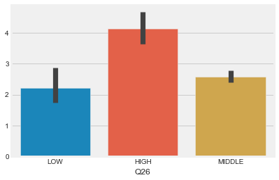

```python
d = pd.concat([data.Q26,q9],axis=1)
sns.barplot(x=data.Q26, y=q9,data=d)
```

상관관계 존재

```python
q9.name='salary'
ndata=pd.concat([ndata,q9],axis=1)
```

**Q10**

```python
data.Q10.unique()
```

```
array(['No (we do not use ML methods)', 'I do not know',
       'We recently started using ML methods (i.e., models in production for less than 2 years)',
       'We have well established ML methods (i.e., models in production for more than 2 years)',
       'We are exploring ML methods (and may one day put a model into production)',
       'We use ML methods for generating insights (but do not put working models into production)'],
      dtype=object)
```

```python
encode={'I do not know':0, 'No (we do not use ML methods)':0,
       'We use ML methods for generating insights (but do not put working models into production)':1,
       'We are exploring ML methods (and may one day put a model into production)':2,
       'We recently started using ML methods (i.e., models in production for less than 2 years)':3,
       'We have well established ML methods (i.e., models in production for more than 2 years)':4}
q10=data.Q10.copy()
q10=q10.replace(encode)
q10[q10.isna()]=0
ndata = pd.concat([ndata,q10],axis=1)
```

```python
ndata.shape
```

```
(13406, 52)
```

## Q11-

```python
# data = data.drop([t for t in data.columns if 'OTHER_TEXT' in t],axis=1)
```

```python
def to_onehot(i):
    num = 'Q'+str(i)
    q=data[[t for t in data.columns if num in t]]
    q = q.drop([t for t in q.columns if 'OTHER_TEXT' in t],axis=1)
    q=q.fillna(0)
    q_r = []
    for col in q.columns:
        if q[col].unique()[0]!=0:
            s = q[col].unique()[0]
            q_r.append(s)
        else:
            s = q[col].unique()[1]
            q_r.append(s)
        q[col]=q[col].replace(s,1)
    q.columns=q_r
    return q
```

## Q11

```python
q11=to_onehot(11)
q11=q11.idxmax(axis=1)
q11.head()

# data=data.drop(['Q11_OTHER_TEXT'],axis=1)
# data[[t for t in data.columns if 'Q11' in t]]=to_onehot(11)
# data[[t for t in data.columns if 'Q11' in t]].head()
```

```
1    None of these activities are an important part...
2    Analyze and understand data to influence produ...
4                                                Other
6    None of these activities are an important part...
7    Build and/or run a machine learning service th...
dtype: object
```

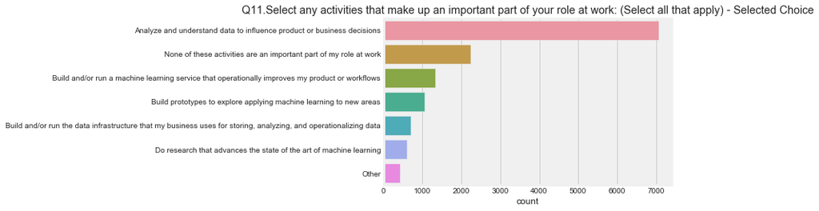

```python
order=q11.value_counts(ascending=False).index
sns.countplot(y=q11,order=order)
plt.title('Q11.' + qs.iloc[0,11+1])
plt.show()
```

```python
q11=to_onehot(11)
q11.columns = ['11_'+str(col) for col in q11.columns]
q11.head()
```

|  | 11_Analyze and understand data to influence product or business decisions | 11_Build and/or run a machine learning service that operationally improves my product or workflows | 11_Build and/or run the data infrastructure that my business uses for storing, analyzing, and operationalizing data | 11_Build prototypes to explore applying machine learning to new areas | 11_Do research that advances the state of the art of machine learning | 11_None of these activities are an important part of my role at work | 11_Other |
| --- | --- | --- | --- | --- | --- | --- | --- |
| 1 | 0 | 0 | 0 | 0 | 0 | 1 | 0 |
| 2 | 1 | 0 | 0 | 0 | 0 | 0 | 0 |
| 4 | 0 | 0 | 0 | 0 | 0 | 0 | 1 |
| 6 | 0 | 0 | 0 | 0 | 0 | 1 | 0 |
| 7 | 0 | 1 | 0 | 0 | 0 | 0 | 0 |

```python
#Add None of these & Others - to others
q11.iloc[:,-1]=q11.iloc[:,-2]+q11.iloc[:,-1]
q11=q11.drop(q11.columns[-2],axis=1)
```

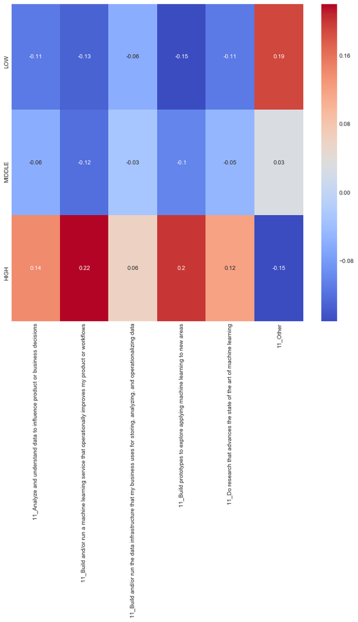

```python
cor_mat=round(pd.concat([confdummy,q11],axis=1,keys=['r','q']).corr().loc['r','q'],2)
plt.figure(figsize=(10,10))
sns.heatmap(cor_mat,cmap='coolwarm',annot=True)
```

```python
ndata=pd.concat([ndata,q11],axis=1)
```

## Q12

원래부터 숫자로 onehot encoding 되어있었음

```python
q12=data[[t for t in data.columns if 'Q12' in t]]
q12=q12.iloc[:,1:]
q12=q12.astype(int)
q12[q12!=-1]=1
q12[q12==-1]=0
q12.head()
```

|  | Q12_Part_1_TEXT | Q12_Part_2_TEXT | Q12_Part_3_TEXT | Q12_Part_4_TEXT | Q12_Part_5_TEXT | Q12_OTHER_TEXT |
| --- | --- | --- | --- | --- | --- | --- |
| 1 | 1 | 0 | 0 | 0 | 0 | 0 |
| 2 | 0 | 0 | 0 | 1 | 0 | 0 |
| 4 | 0 | 1 | 0 | 0 | 0 | 0 |
| 6 | 1 | 0 | 0 | 0 | 0 | 0 |
| 7 | 0 | 0 | 0 | 1 | 0 | 0 |

```python
q12.columns =['Basic statistical software (Microsoft Excel, Google Sheets, etc.)',
                             'Advanced statistical software (SPSS, SAS, etc.)',
                             'Business intelligence software (Salesforce, Tableau, Spotfire, etc.)',
                             'Local or hosted development environments (RStudio, JupyterLab, etc.)',
                             'Cloud-based data software & APIs (AWS, GCP, Azure, etc.)','Other']
```

```python
q=q12.idxmax(axis=1)
```

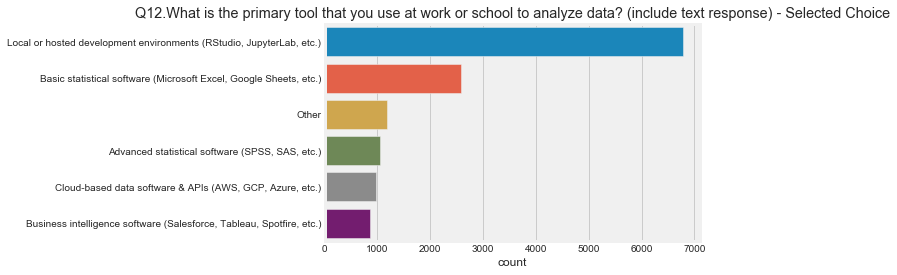

```python
order=q.value_counts(ascending=False).index
sns.countplot(y=q, order=order)
# plt.xticks(rotation=60)
plt.title('Q12.' + qs.iloc[0,12+1])
plt.show()
```

```python
len(q12[q12.iloc[:,1].isna()])
```

```
0
```

```python
q12.columns=['12_'+ str(col) for col in q12.columns]
ndata=pd.concat([ndata,q12],axis=1)
```

## Q13

```python
def plotnprocess(data,i,title):
    s='Q'+str(i)
    if s+'_OTHER_TEXT' in data.columns:
        data=data.drop([s+'_OTHER_TEXT'],axis=1)
    df=to_onehot(i)

    x=df.sum(axis=0)
    x=x.sort_values()
    plt.figure(figsize=(10,7))
    x.plot(kind='barh')
    plt.title(title)
    plt.show()

    df.columns=[str(i)+'_'+str(col) for col in df.columns]
    return df
```

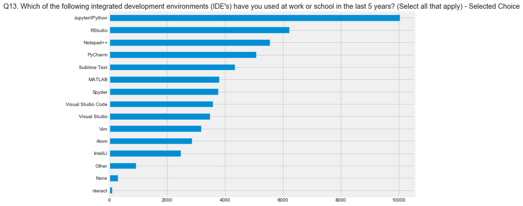

```python
q13=plotnprocess(data,13,'Q13. '+qs.iloc[0,13+1])
ndata=pd.concat([ndata,q13],axis=1)
```

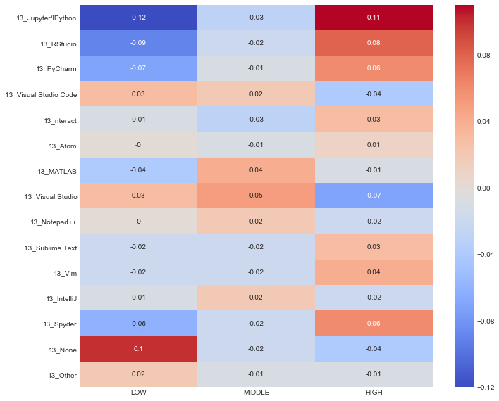

```python
cor_mat=round(pd.concat([q13,confdummy],axis=1,keys=['r','q']).corr().loc['r','q'],2)
plt.figure(figsize=(10,10))
sns.heatmap(cor_mat,cmap='coolwarm',annot=True)
```

```python
ndata.head()
```

|  | 1_Female | 1_Male | age | 3_Africa | 3_Asia | 3_Europe | 3_NorthAmerica | 3_Oceania | 3_SouthAmerica | 4_Bachelor’s degree | ... | 13_Atom | 13_MATLAB | 13_Visual Studio | 13_Notepad++ | 13_Sublime Text | 13_Vim | 13_IntelliJ | 13_Spyder | 13_None | 13_Other |
| --- | --- | --- | --- | --- | --- | --- | --- | --- | --- | --- | --- | --- | --- | --- | --- | --- | --- | --- | --- | --- | --- |
| 1 | 0 | 1 | 3 | 0 | 1 | 0 | 0 | 0 | 0 | 1 | ... | 0 | 0 | 0 | 0 | 0 | 0 | 0 | 0 | 1 | 0 |
| 2 | 1 | 0 | 3 | 0 | 0 | 0 | 1 | 0 | 0 | 0 | ... | 0 | 1 | 0 | 0 | 0 | 0 | 0 | 0 | 0 | 0 |
| 4 | 0 | 1 | 1 | 0 | 1 | 0 | 0 | 0 | 0 | 0 | ... | 0 | 0 | 0 | 0 | 0 | 0 | 0 | 0 | 0 | 0 |
| 6 | 0 | 1 | 4 | 0 | 0 | 0 | 0 | 0 | 1 | 0 | ... | 0 | 0 | 0 | 0 | 0 | 0 | 0 | 0 | 0 | 0 |
| 7 | 0 | 1 | 0 | 0 | 1 | 0 | 0 | 0 | 0 | 0 | ... | 1 | 0 | 1 | 1 | 1 | 0 | 1 | 1 | 0 | 0 |

5 rows × 79 columns

## Q14

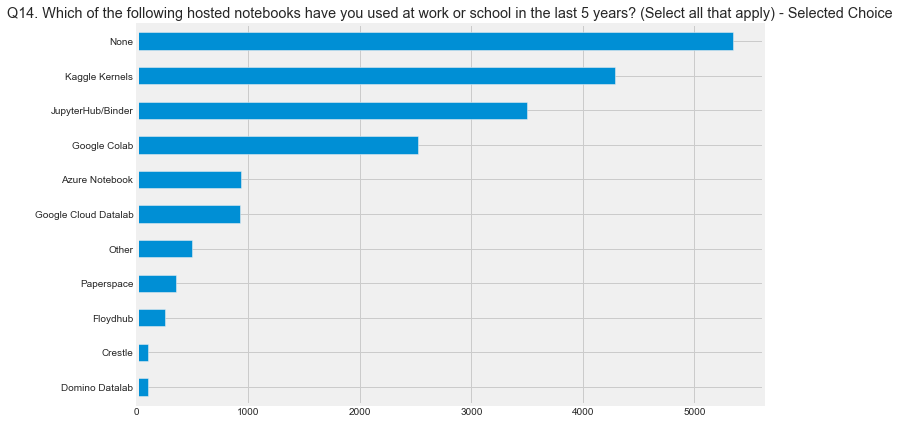

```python
q14=plotnprocess(data,14,'Q14. '+qs.iloc[0,14+1])
ndata=pd.concat([ndata,q14],axis=1)
```

None의 의미 = 쓰지 않는다? or 이 중에 없다?

## Q15-Q16

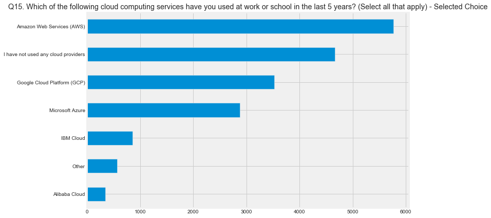

```python
q15=plotnprocess(data,15,'Q15. '+qs.iloc[0,15+1])
ndata=pd.concat([ndata,q15],axis=1)
```

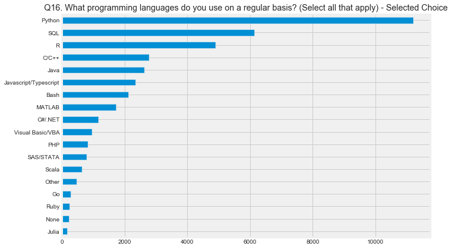

```python
q16=plotnprocess(data,16,'Q16. '+qs.iloc[0,16+1])
ndata=pd.concat([ndata,q16],axis=1)
```

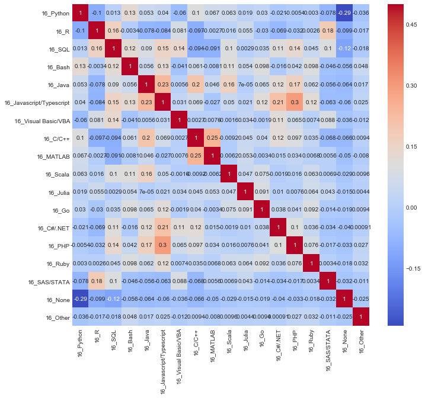

```python
corr_matrix = q16.corr()
plt.figure(figsize = (10,10))
sns.heatmap(corr_matrix, vmax=0.5, cmap='coolwarm', annot=True)
```

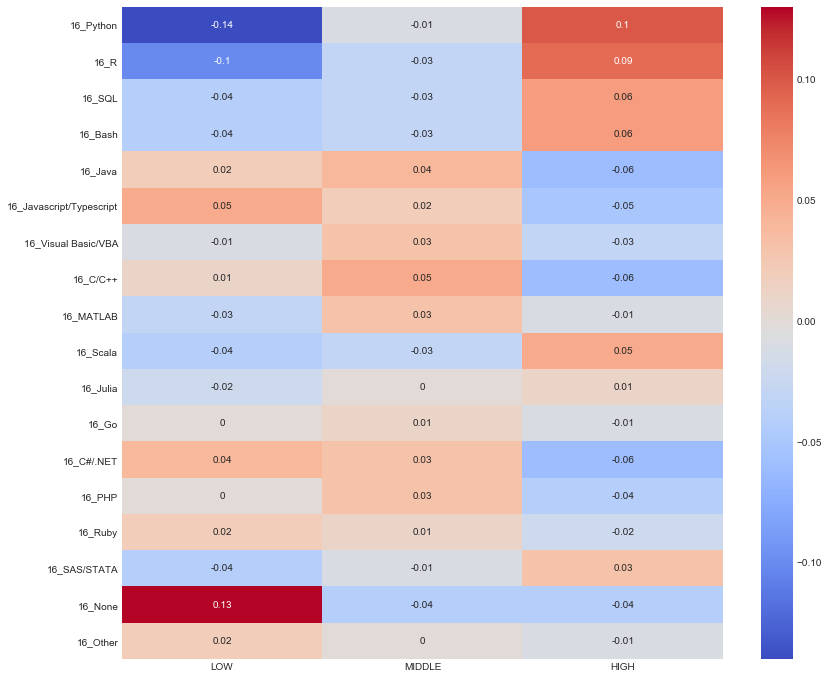

```python
cor_mat=round(pd.concat([q16,confdummy],axis=1,keys=['r','q']).corr().loc['r','q'],2)
plt.figure(figsize=(12,12))
sns.heatmap(cor_mat,cmap='coolwarm',annot=True)
```

## Q17(제외)

## Q18(제외)

## Q19

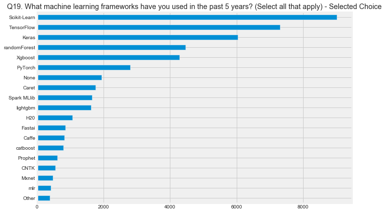

```python
q19=plotnprocess(data,19,'Q19. '+qs.iloc[0,19+1])
ndata=pd.concat([ndata,q19],axis=1)
```

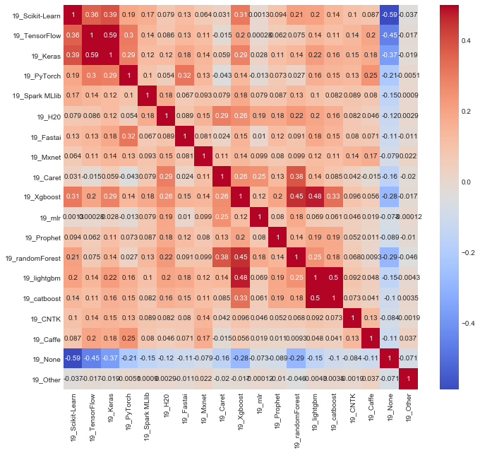

```python
corr_matrix = q19.corr()
plt.figure(figsize = (10,10))
sns.heatmap(corr_matrix, vmax=0.5, cmap='coolwarm', annot=True)
```

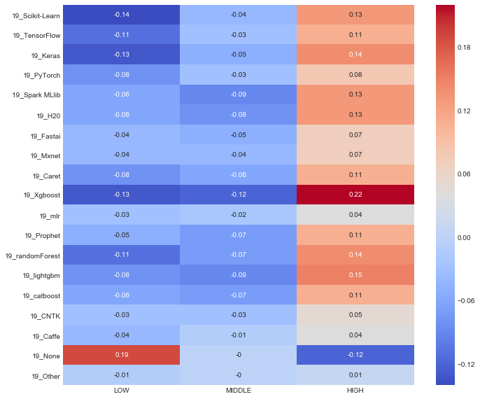

```python
cor_mat=round(pd.concat([q19,confdummy],axis=1,keys=['r','q']).corr().loc['r','q'],2)
plt.figure(figsize=(10,10))
sns.heatmap(cor_mat,cmap='coolwarm',annot=True)
```

## Q20(제외)

## Q21.

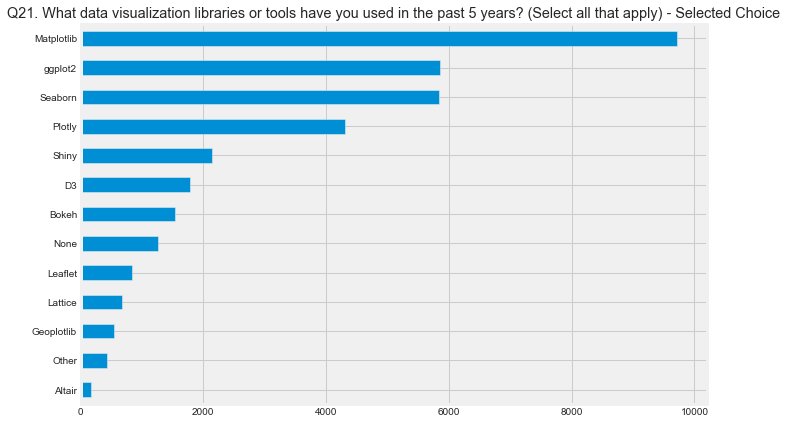

```python
q21=plotnprocess(data,21,'Q21. '+qs.iloc[0,21+1])
ndata=pd.concat([ndata,q21],axis=1)
```

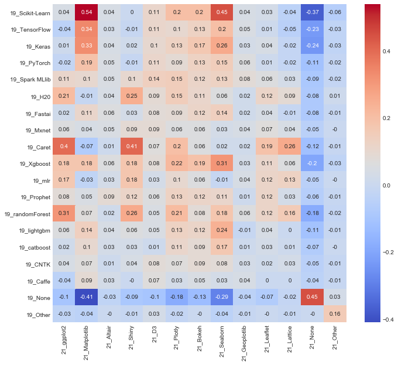

```python
cor_mat=round(pd.concat([q19,q21],axis=1,keys=['r','q']).corr().loc['r','q'],2)
plt.figure(figsize=(10,10))
sns.heatmap(cor_mat,cmap='coolwarm',annot=True)
```